# Practical 3b - Linear Regression: Frequentist *vs* Bayesian analysis

Bayesian modelling for Spatial and Spatio-Temporal data

In this practical we will develop a multiple linear regression model on real data and we will compare Frequentist and Bayesian methods.

The aims of this practical are to get a general understanding of how to:

1. Perform a simple Bayesian analysis of real data using the `R` package `INLA`, and compare this with a Frequentist analysis;
2. Download and process data from `Fingertips` data tool, which is a major public repository of population and public health indicators for England;
3. Cite automatically `R` packages in R Markdown

In detail, `Fingertips`, is a large repository of indicators for public health data. Data are structured by thematic profiles, which cover a wide range of health related topics. Here we investigate the relationship between socio-economic deprivation and life-expectancy at birth. We will use the package `fingertipsR` in `R` to obtain the data.

In addition to `fingertipsR` and `INLA`, we use the following packages:

- `dplyr`, which includes tools for data manipulation;
- `tidyr`, which includes tools to create tidy data;
- `stringr`, which provide a set of functions designed to work with strings;
- `jtools`, which includes tools for summarizing and visualizing regression models;
- `ggplot2`, which is an excellent package for data visualization. It implements the *grammar of graphics*, proposing a scheme for data visualization which breaks up graphs into semantic components such as scales and layers.

# 1. Install and load R-packages

- To start with, install the packages `fingertipsR`

```r
# Enable repository from ropensci
options(repos = c(
  ropensci = 'https://ropensci.r-universe.dev',
  CRAN = 'https://cloud.r-project.org'))

# Download and install fingertipsR in R
install.packages('fingertipsR')
# or use
# remotes::install_github("rOpenSci/fingertipsR", build_vignettes = TRUE, dependencies = "suggests")
```

- Then load the packages needed for this lab

```r
# Load the package fingertipsR
library("fingertipsR")
library("INLA")

# Load the other packages
packages = c("ggplot2", "dplyr", "tidyr", "stringr", "jtools")

# Install packages not yet installed
installed_packages <- packages %in% rownames(installed.packages())
if (any(installed_packages == FALSE)) {
  install.packages(packages[!installed_packages])
}

# Packages loading
invisible(lapply(packages, library, character.only = TRUE))
```

# 2. How to cite R packages?

- To cite a R package, we can use the command `citation` and this will return the reference, including the bib format

```r
citation("ggplot2")
```

```
##
##
##   H. Wickham. ggplot2: Elegant Graphics for Data Analysis.
##   Springer-Verlag New York, 2016.
##
## A BibTeX entry for LaTeX users is
##
##   @Book{,
##     author = {Hadley Wickham},
##     title = {ggplot2: Elegant Graphics for Data Analysis},
##     publisher = {Springer-Verlag New York},
##     year = {2016},
##     isbn = {978-3-319-24277-4},
##     url = {https://ggplot2.tidyverse.org},
##   }
```

- However, if we want to city all the packages used in this lab automatically, we can proceed by setting a chunk of code for automatic citations of the R packages. This is obtained via the function `knitr::write_bib()`, which generates citation entries to a file and adds keys automatically

```r
# Automatically create a bib database for R packages
knitr::write_bib(c(
  .packages(), packages
), 'packages.bib')
```

Here, `.packages()` returns the names of all packages loaded in the current R session. This makes sure all packages being used will have their citation entries written to the .bib file (for details you can check the online freely available book Xie, Dervieux, and Riederer (2020)).

# 3. Get and process the data

- We download the data using `fingertipsR` package. For details about the package, you can check the vignettes

```r
browseVignettes("fingertipsR")
```

- We start by examining which profiles and domains are available in the `fingertipsR` package, then we download data from the *Public Health Outcomes Framework* profile, finally we select the indicator on *Healthy Life Expectancy at Birth*

```r
profiles = profiles()

profiles = profiles[grepl("Public Health Outcomes Framework", profiles$ProfileName),]

head(profiles)
```

- To check which indicators constitute a domain, we can use the `indicators()` function

```r
profid = 19 # 19 is the ProfileID of the "Public Health Outcomes Framework"
inds = indicators(ProfileID = profid)

print(inds[grepl("Healthy", inds$IndicatorName), c("IndicatorID", "IndicatorName")])
```

- Now, we extract the life expectancy at birth indicator using the `fingertips_data()` function. It corresponds to the IndicatorID equal to 90362.  
  Unless specified with an `AreaTypeID` code, it downloads data for Upper Tier Local Authorities (AreaTypeID equal to 102) if available (also described as County and Unitary Authorities).

Life expectancy at birth will be our response variable. Then, we will use the level of deprivation and sex as explanatory variables.

```r
# Extract the data using the fingertips_data() function
# ?fingertips_data
LifeExp = fingertips_data(IndicatorID = 90362, AreaTypeID = 102)
head(LifeExp)

LifeExp = LifeExp %>%
select(IndicatorID, IndicatorName, AreaCode, AreaName, AreaType,
Sex, Age, Timeperiod, Value) %>%
mutate(IndicatorName =
str_trunc(as.character(IndicatorName), width = 20, "right"),
AreaName = str_trunc(as.character(AreaName), width = 20, "right"))#%>%
#head()

unique(LifeExp$Timeperiod)
unique(LifeExp$AreaType)
```

- Note that to find available areas and relevant AreaTypeID codes, we can use the `area_types()` function

```r
areas = area_types()
areas %>%
  select(AreaTypeID, AreaTypeName) %>%
  distinct()
```

- We recover the index of deprivation for the year 2015 and join it with LifeExp data. The Index of Multiple Deprivation 2015 (IMD 2015) is an overall measure of multiple deprivation experienced by people living in an area (for details see https://assets.publishing.service.gov.uk/government/uploads/system/uploads/attachment_data/file/465791/English_Indices_of_Deprivation_2015_-_Statistical_Release.pdf).

```r
# To check what AreaTypeIDs are available
# indicator_areatypes()

Dep15 = deprivation_decile(AreaTypeID = 102, Year = 2015)
head(Dep15)

# Join data
# Restrict to relevant geography (Upper Tier Local
# Authority) and time (years 2014-16)
LifeExp = LifeExp %>%
filter(AreaType == "Counties & UAs (pre Apr 2019)" & Timeperiod == "2014 - 16") %>%
left_join(., Dep15) # merge in deprivation data

head(LifeExp)
```

- Produce a summary of the data to check completeness

```r
summary(LifeExp)
```

we can see the the Value of life expectancy is missing for 4 observations. For the purpose of this practical, drop the rows with missing observations and call the new data set as LifeExp.nomis

```r
#Remove rows that contains NA's
LifeExp.nomis = LifeExp %>% drop_na()
```

- Plot the life expectancy *vs* the deprivation score by sex using `ggplot2`. In particular, inside `aes()` (aesthetic), we specify the response variable with `y = Value`, the continuous explanatory variable with `x = IMDscore` and the categorical explanatory variable with `colour = Sex`. The opacity of the `geom` (geometric object; here `geom_point`) is governed by values of `alpha`. It ranges from 0 to 1, with lower values corresponding to more transparent colors. Note that we use `+` to connect the elements of the graph.

```r
LifeExp.nomis %>%
  ggplot(aes(x = IMDscore, y = Value, colour = Sex)) +
  geom_point(alpha = 0.2) +
  scale_x_continuous("IMD score") +
  scale_y_continuous("Life expectancy")
```

- The IMD score is available also in deciles. It has been processed so Decile 1 represents the most deprived 10% (or Decile) of small areas in England, and Decile 10 represents the least deprived 10%. Note however there is no definitive threshold above which an area is described as deprived; the Indices of Deprivation are a continuous scale of deprivation.

Here we further manipulate the data, inspecting the difference between the most and least deprived areas by sex.

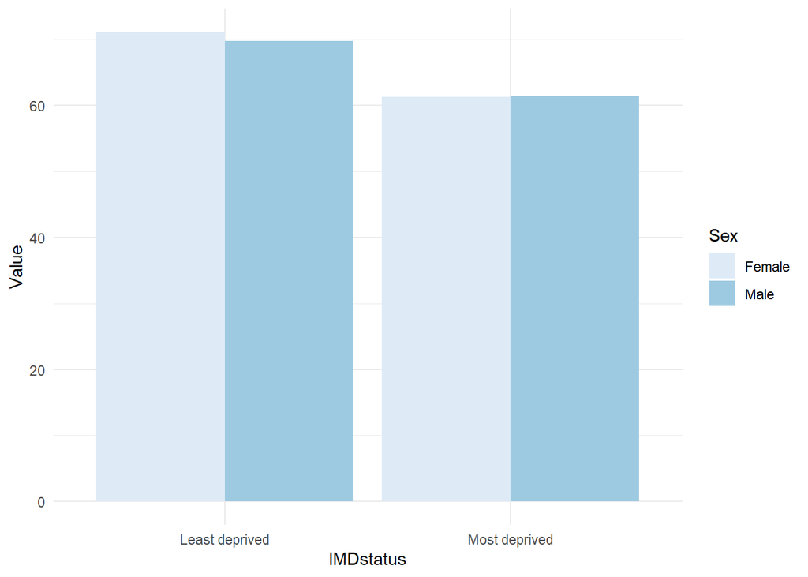

```r
# Filter the data
df.plot = LifeExp.nomis %>%
  filter(decile == 1 | decile == 10)

# Create new variable that identifies the most and least deprived areas
df.plot = df.plot %>%  # mutate() adds new variables and preserves existing ones
  mutate(IMDstatus = case_when(
    decile == 1 ~ "Most deprived",
    decile == 10 ~ "Least deprived"
  ))

# Grouped barplot using ggplot2
ggplot(df.plot,
       aes(x = IMDstatus,
           y = Value,
           fill = Sex)) +
  geom_bar(stat = "identity",
           position = "dodge") +
  scale_fill_brewer(palette="Blues")+
   theme_minimal()
```

Note that the default behavior of `geom_bar()` is to count the rows for each x value. If we explicitly say `stat = "identity"` in `geom_bar()`, we are telling ggplot2 to skip the aggregation and that we will provide the y values.

- What you conclude from these preliminary exploratory analyses?

# 4. Models

We specify now the multiple linear regression model, taking the value of life expectancy at birth as response variable, and deprivation score and sex as explanatory variables.

Let $y_i$ be the life expectancy in unit $i$ for $i=1, \dots, n$ (i.e. response variable) and $x_{ji}$ be the $j$-th covariate available in unit $i$, i.e. multiple deprivation score and sex. The model to be fitted is the following:

$$y_i = \beta_0 + \sum_{j=1}^{2} \beta_j
x_{ji} + \epsilon_{i}$$

where:

- $\beta_0$ is the intercept
- $\beta_j$ for $j=1,2$ are the coefficients associated with the explanatory variables, i.e. $\beta_1$ is the parameter for the effect of the multiple deprivation score `IMDscore` and $\beta_2$ is the parameter for the effect of `Sex`. The latter is categorical variable, therefore it has a baseline level in `R`. The parameter associated with the categorical variable estimates the difference in the response variable in a group different from the baseline. Since the letter *f* precedes *m* in the alphabet, `R` will take Female as the baseline level.
- $\epsilon_i$ for $i=1,\dots,n$ is an error term Gaussian distributed with mean zero and variance $\sigma^{2}_{\epsilon}$.

## 4.1 Frequentist model

- We fit the standard linear model in `R`. First define the formula, and call is as `my.formula`. Then, fit the model (call is as `m1`) and obtain and check the estimated coefficients. Finally, get the 95% confidence interval (95% CI) using the function `sumn` from the package `jtools` (i.e. `summ(m1, confint = TRUE, digits = 3)`)
- How would you interpret these results?

## 4.2 Bayesian model

- Now, we fit a Bayesian linear regression model using `INLA` with the default priors. Here, the main function to run a model is `inla()`, which takes care of all model fitting. By default:
1. the intercept has a Gaussian prior with mean and precision equal to zero.
2. the coefficients of the fixed effects also have a Gaussian prior with zero mean and precision equal to 0.001.
3. the prior on the precision of the error term is a Gamma distribution with parameters 1 and 0.00005 (shape and rate, respectively).
- Fit the model using the function `inla` and call the result as `m2`. Then, obtain a summary of the model using the function `summary()`, which displays summary statistics on the posterior marginals of the model latent effects, hyperparameters and other quantities of interest.
- Now, obtain the posterior summary of the fixed effect and hyperparameters
- How you can see from the summary, by default the posterior summaries of the precision is outputted. However, we are often interested in the posterior mean of the standard deviation. Obtain its estimate using the function `inla.emarginal` as we did in Practical 3a
- Now, plot the posterior distribution of the measurement error standard deviation
- Explore the names of the fixed effects

```r
# Check the fixed effect names
names(m2$marginals.fixed)
```

```
## [1] "(Intercept)" "IMDscore"    "SexMale"
```

- Plot the marginal posterior distributions of $\beta_0$, $\beta_1$ and $\beta_2$, tacking advantage of the function `inla.smarginal`

# 5. Compare the INLA model output to the `lm` output

Now we compare the estimates obtained from the Bayesian and the frequentist model

```r
cbind(m2$summary.fixed[,1:2],summary(m1)$coef[,1:2])
```

```
##                   mean         sd   Estimate Std. Error
## (Intercept) 71.5035103 0.35938971 71.5035255 0.35977125
## IMDscore    -0.3632051 0.01394136 -0.3632051 0.01395613
## SexMale     -0.5396391 0.22382930 -0.5396661 0.22407201
```

Here, the first two columns are the posterior means and SDs from the INLA model, while the third and fourth are the corresponding values from the frequentist model.

What do you conclude?

# 6. Compute the fitted values

- To compute the fitted value, we need to compute the posterior means of the linear predictors. This is performed by including `control.predictor=list(compute=TRUE)` within the `inla` function. Modify the model `m2` to include it, and call the new model as `m3`.
- Obtain the fitted values from the Bayesian model and compare the posterior means to the fitted values obtained from the `lm()` function:

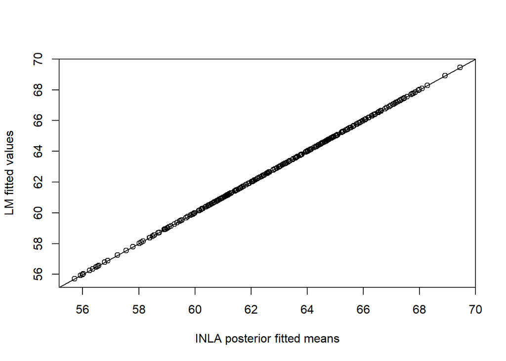

```r
ypostmean = m3$summary.linear.predictor[,1]

plot(ypostmean, as.vector(m1$fitted.values), xlab="INLA posterior fitted means", ylab="LM fitted values")
abline(0,1)
```

# References

Bakka, Haakon, Håvard Rue, Geir-Arne Fuglstad, Andrea I. Riebler, David Bolin, Janine Illian, Elias Krainski, Daniel P. Simpson, and Finn K. Lindgren. 2018. “Spatial Modelling with INLA: A Review.” *WIRES (Invited Extended Review)* xx (Feb): xx–. http://arxiv.org/abs/1802.06350.

Bates, Douglas, Martin Maechler, and Mikael Jagan. 2022. *Matrix: Sparse and Dense Matrix Classes and Methods*. https://CRAN.R-project.org/package=Matrix.

Bivand, Roger S., Edzer Pebesma, and Virgilio Gomez-Rubio. 2013. *Applied Spatial Data Analysis with R, Second Edition*. Springer, NY. https://asdar-book.org/.

De Coninck, Arne, Bernard De Baets, Drosos Kourounis, Fabio Verbosio, Olaf Schenk, Steven Maenhout, and Jan Fostier. 2016. “Needles: Toward Large-Scale Genomic Prediction with Marker-by-Environment Interaction.” *Genetics* 203 (1): 543–55. https://doi.org/10.1534/genetics.115.179887.

Fox, Sebastian, and Julian Flowers. 2022. *fingertipsR: Fingertips Data for Public Health*.

Kourounis, D., A. Fuchs, and O. Schenk. 2018. “Towards the Next Generation of Multiperiod Optimal Power Flow Solvers.” *IEEE Transactions on Power Systems* PP (99): 1–10. https://doi.org/10.1109/TPWRS.2017.2789187.

Lindgren, Finn, and Håvard Rue. 2015. “Bayesian Spatial Modelling with R-INLA.” *Journal of Statistical Software* 63 (19): 1–25. http://www.jstatsoft.org/v63/i19/.

Lindgren, Finn, Håvard Rue, and Johan Lindström. 2011. “An Explicit Link Between Gaussian Fields and Gaussian Markov Random Fields: The Stochastic Partial Differential Equation Approach (with Discussion).” *Journal of the Royal Statistical Society B* 73 (4): 423–98.

Long, Jacob A. 2022. *Jtools: Analysis and Presentation of Social Scientific Data*. https://jtools.jacob-long.com.

Martins, Thiago G., Daniel Simpson, Finn Lindgren, and Håvard Rue. 2013. “Bayesian Computing with INLA: New Features.” *Computational Statistics and Data Analysis* 67: 68–83.

Pebesma, Edzer J., and Roger S. Bivand. 2005. “Classes and Methods for Spatial Data in R.” *R News* 5 (2): 9–13. https://CRAN.R-project.org/doc/Rnews/.

Pebesma, Edzer, and Roger Bivand. 2022. *Sp: Classes and Methods for Spatial Data*. https://CRAN.R-project.org/package=sp.

R Core Team. 2022. *R: A Language and Environment for Statistical Computing*. Vienna, Austria: R Foundation for Statistical Computing. https://www.R-project.org/.

Revolution Analytics, and Steve Weston. n.d. *Foreach: Provides Foreach Looping Construct*.

Rue, Havard, Finn Lindgren, and Elias Teixeira Krainski. 2022. *INLA: Full Bayesian Analysis of Latent Gaussian Models Using Integrated Nested Laplace Approximations*.

Rue, Håvard, Sara Martino, and Nicholas Chopin. 2009. “Approximate Bayesian Inference for Latent Gaussian Models Using Integrated Nested Laplace Approximations (with Discussion).” *Journal of the Royal Statistical Society B* 71: 319–92.

Rue, Håvard, Andrea I. Riebler, Sigrunn H. Sørbye, Janine B. Illian, Daniel P. Simpson, and Finn K. Lindgren. 2017. “Bayesian Computing with INLA: A Review.” *Annual Reviews of Statistics and Its Applications* 4 (March): 395–421. http://arxiv.org/abs/1604.00860.

Verbosio, Fabio, Arne De Coninck, Drosos Kourounis, and Olaf Schenk. 2017. “Enhancing the Scalability of Selected Inversion Factorization Algorithms in Genomic Prediction.” *Journal of Computational Science* 22 (Supplement C): 99–108. https://doi.org/10.1016/j.jocs.2017.08.013.

Wickham, Hadley. 2016. *Ggplot2: Elegant Graphics for Data Analysis*. Springer-Verlag New York. https://ggplot2.tidyverse.org.

———. 2022. *Stringr: Simple, Consistent Wrappers for Common String Operations*. https://CRAN.R-project.org/package=stringr.

Wickham, Hadley, Winston Chang, Lionel Henry, Thomas Lin Pedersen, Kohske Takahashi, Claus Wilke, Kara Woo, Hiroaki Yutani, and Dewey Dunnington. 2022. *Ggplot2: Create Elegant Data Visualisations Using the Grammar of Graphics*. https://CRAN.R-project.org/package=ggplot2.

Wickham, Hadley, Romain François, Lionel Henry, and Kirill Müller. 2022. *Dplyr: A Grammar of Data Manipulation*. https://CRAN.R-project.org/package=dplyr.

Wickham, Hadley, and Maximilian Girlich. 2022. *Tidyr: Tidy Messy Data*. https://CRAN.R-project.org/package=tidyr.

Xie, Yihui, Christophe Dervieux, and Emily Riederer. 2020. *R Markdown Cookbook*. Chapman; Hall/CRC.